# Phoneme Classification

- Show All Code
- Hide All Code
- View Source

Project

Solve a classification problem: Phoneme Classification.

Author

Wu Hao

Published

2024/12/31

## Objectives:

Solve a classification problem: Phoneme Classification.

## Global Settings

We import all the packages here to make us easier to call.

```python
# Numerical Operations
import numpy as np
import math

# Pytorch
import torch
from torch.utils.data import DataLoader, Dataset, random_split
import torch.nn as nn

# For plotting learning curve
from torch.utils.tensorboard import SummaryWriter

# Image Processing
import cv2
# from torchvision import transforms

# Reading/Writing Data
import scipy.io as scio
import os
import csv
import pandas as pd

# Training Process
import sys
import time

# Showing Results
from IPython.display import display
from IPython.display import Image

# training optimization
import gc
```

For the reproducibility of the experiment, we fix the random number generator seeds here.

```python
#Fixes random number generator seeds for reproducibility.
def same_seed(seed):
    torch.backends.cudnn.deterministic = True
    torch.backends.cudnn.benchmark = False
    np.random.seed(seed)
    torch.manual_seed(seed)
    if torch.cuda.is_available():
        torch.cuda.manual_seed_all(seed)
```

## Configurations

```python
device = 'cuda' if torch.cuda.is_available() else 'cpu'
config = {
    'seed': 342425,       # seed number, we can pick lucky number. :)
    'valid_ratio': 0.8,   # validation_size = train_size * valid_ratio
    'n_epochs': 20,     # Number of epochs.
    'batch_size': 2048,
    'learning_rate': 1e-4,
    'concat_frames': 19,
    'early_stop': 8,    # If model has not improved for this many consecutive epochs, stop training.
    'hidden_layers': 3,  # Classifier Network
    'hidden_dim': 1024,   # Classifier Network
    'save_path': './libriphone/model.ckpt'  # our model will be saved here.
}
```

## Dataset

We can download data from [LibriSpeech](https://www.kaggle.com/c/ml2023spring-hw2/data)

Some basic information about the speech dataset:

```python
def count_files_in_directory(directory_path):
    files = [f for f in os.listdir(directory_path) if os.path.isfile(os.path.join(directory_path, f))]
    return len(files)

train_datafile = os.path.join('Libriphone','feat','train')
test_datafile = os.path.join('Libriphone','feat','test')

print(f"We have {count_files_in_directory(train_datafile)} train data.")
print(f"We have {count_files_in_directory(test_datafile)} test data.\n")

# show the structure of data_file.
def print_tree(path, depth=1, current_depth=0):
    if current_depth > depth:
        return
    for item in os.listdir(path):
        item_path = os.path.join(path, item)
        print("    " * current_depth + "|-- " + item)
        if os.path.isdir(item_path):
            print_tree(item_path, depth, current_depth + 1)
print("The structure of data_file: ")
print_tree("./libriphone", depth=1)
```

```
We have 3429 train data.
We have 857 test data.

The structure of data_file:
|-- feat
    |-- test
    |-- train
|-- model.ckpt
|-- pred.csv
|-- test_split.txt
|-- train_labels.txt
|-- train_split.txt
```

1. train_split.txt - train metadata
2. train_labels.txt - train labels
3. test_split.txt - test metadata
4. feat/train/{id}.pt and feat/test/{id}.pt - 39-dim MFCC w/ CMVN for each utterance(audio)

## Training Code

### Dataset Processing

We should construct the train_data, valid_data and test_data.

First, we split the data from ./libriphone/feat/train into train_data and valid_data.

```python
#get labels from .txt
def take_train_label(phoneme_path):
    label_dict = {}
    for line in open(os.path.join(phoneme_path, 'train_labels.txt')).readlines():
        line = line.strip('\n').split(' ')
        label_dict[line[0]] = [int(p) for p in line[1:]]
    print(f"Length of labels is {len(label_dict)}")
    return label_dict

#phoneme_path: address of {.txt}
#ratio: split ratio
def train_valid_split(phoneme_path, ratio, seed):

    usage_list = open(os.path.join(phoneme_path, 'train_split.txt')).readlines()
    usage_list = [line.strip('\n') for line in usage_list]
    # generate random indices
    permuted_indices = torch.randperm(len(usage_list), generator=torch.Generator().manual_seed(seed)).tolist()
    usage_list = [usage_list[i] for i in permuted_indices]
    train_size = int(ratio * len(usage_list))
    train_list = usage_list[:train_size]
    valid_list = usage_list[train_size:]

    return train_list, valid_list
```

Since a phoneme may span several frames and is dependent to past and future frames, we should concatenate neighboring phonemes for training to achieve higher accuracy.

```python
# For the input tensor x shift n
def shift(x, n):
    if n < 0: # right shift
        left = x[0].repeat(-n, 1)
        right = x[:n]
    elif n > 0: # left shift
        right = x[-1].repeat(n, 1)
        left = x[n:]
    else:
        return x
    return torch.cat((left, right), dim=0)

# feature enhancement
def concat_feat(x, concat_n):
    assert concat_n % 2 == 1 # n must be odd
    if concat_n < 2:
        return x
    seq_len, feature_dim = len(x), len(x[0])
    x = x.repeat(1, concat_n)
    x = x.view(seq_len, concat_n, feature_dim).permute(1, 0, 2)
    mid = (concat_n // 2)
    for r_idx in range(1, mid+1):
        x[mid + r_idx, :] = shift(x[mid + r_idx], r_idx)
        x[mid - r_idx, :] = shift(x[mid - r_idx], -r_idx)

    return x.permute(1, 0, 2).view(seq_len, concat_n * feature_dim)

print("Objectives: Extend 1-frame features to a assigned frame\n")
print("Starting Test")
x = torch.tensor([
    [1, 2, 3],
    [4, 5, 6],
    [7, 8, 9],
    [10, 11, 12]
])
print(f"Original tensor is\n {x}\n")
concat_n = 3
print(f"Extend to {concat_n}-frame features including the center and its context.")
concat_result = concat_feat(x, concat_n)
print(f"Tensor after concatenating is\n {concat_result}")
```

```
Objectives: Extend 1-frame features to a assigned frame

Starting Test
Original tensor is
 tensor([[ 1,  2,  3],
        [ 4,  5,  6],
        [ 7,  8,  9],
        [10, 11, 12]])

Extend to 3-frame features including the center and its context.
Tensor after concatenating is
 tensor([[ 1,  2,  3,  1,  2,  3,  4,  5,  6],
        [ 1,  2,  3,  4,  5,  6,  7,  8,  9],
        [ 4,  5,  6,  7,  8,  9, 10, 11, 12],
        [ 7,  8,  9, 10, 11, 12, 10, 11, 12]])
```

```python
#data_path: address of {.pt}
#concat_nframes: frames after concatenation
#usage_list: feature
#label: label dictionary
def merge_frame(data_path, concat_nframes, usage_list, label, split='train'): # merge context

    max_len = 3000000
    X = torch.empty(max_len, 39 * concat_nframes) # X: features
    y = torch.empty(max_len, dtype=torch.long) #y: labels
    idx = 0
    for i, fname in enumerate(usage_list):
        train_feature = torch.load(os.path.join(data_path, 'train', f'{fname}.pt'),weights_only=True)
        cur_len = len(train_feature)
        train_feature = concat_feat(train_feature, concat_nframes)
        train_label = torch.LongTensor(label[fname])

        X[idx: idx + cur_len, :] = train_feature
        y[idx: idx + cur_len] = train_label

        idx += cur_len

    X = X[:idx, :]
    y = y[:idx]
    print(f"Shape of {split} feature is [nums, feature_nums]: {X.shape}")
    print(f"Shape of {split} label is {y.shape}\n")

    return X, y

train_label = take_train_label('libriphone')
train_features, valid_features = train_valid_split('libriphone', config["valid_ratio"], config["seed"])
train_features, train_labels = merge_frame('libriphone/feat', config['concat_frames'], train_features, train_label)
valid_features, valid_labels =  merge_frame('libriphone/feat', config['concat_frames'], valid_features, train_label, split='valid')
```

```
Length of labels is 3429
Shape of train feature is [nums, feature_nums]: torch.Size([1675053, 741])
Shape of train label is torch.Size([1675053])

Shape of valid feature is [nums, feature_nums]: torch.Size([441741, 741])
Shape of valid label is torch.Size([441741])
```

So, we’ve got two sets of data — train_data and valid_data, and we’ve also got their features.

And we also need to process the test data.

```python
def test_preprocess(phoneme_path, data_path, concat_nframes):
    usage_list = open(os.path.join(phoneme_path, 'test_split.txt')).readlines()
    usage_list = [line.strip('\n') for line in usage_list]

    max_len = 3000000
    X = torch.empty(max_len, 39 * concat_nframes) # X: features
    idx = 0
    for i, fname in enumerate(usage_list):
        test_feature = torch.load(os.path.join(phoneme_path, data_path, 'test', f'{fname}.pt'),weights_only=True)
        cur_len = len(test_feature)
        test_feature = concat_feat(test_feature, concat_nframes)
        X[idx: idx + cur_len, :] = test_feature
        idx += cur_len

    X = X[:idx, :]
    print(f"Shape of test feature is [nums, feature_nums]: {X.shape}")
    return X

test_features = test_preprocess('libriphone', 'feat', config['concat_frames'])
```

```
Shape of test feature is [nums, feature_nums]: torch.Size([527364, 741])
```

So, we’ve got:

1. train_features, train_labels
2. valid_features, valid_labels
3. test_features

Now, it’s time to construct our dataset.

```python
#x: Features.
#y: Targets, if none, do prediction.
class ImgDataset(Dataset):
    def __init__(self, x, y=None):
        self.x = x
        if y is None:
            self.y = y
        else:
            self.y = torch.LongTensor(y)

    def __getitem__(self, index):
        X = self.x[index]
        if self.y is not None:
            Y = self.y[index]
            return X, Y
        else:
            return X
    def __len__(self):
        return len(self.x)

train_dataset, valid_dataset, test_dataset = ImgDataset(train_features, train_labels), \
                                            ImgDataset(valid_features, valid_labels), \
                                            ImgDataset(test_features)
# free up memory
del train_features, train_labels, valid_features, valid_labels, test_features
gc.collect()

train_loader = DataLoader(train_dataset, batch_size=config['batch_size'], shuffle=True, pin_memory=True)
valid_loader = DataLoader(valid_dataset, batch_size=config['batch_size'], shuffle=False, pin_memory=True)
test_loader = DataLoader(test_dataset, batch_size=config['batch_size'], shuffle=False, pin_memory=True)
```

At this point, we’ve finished building the dataset. With train_loader, we can get bulk data during the training process and pass it to the model. It’s time to construct our model.

### Model

We adopt a network consisting of `hidden_layers+2` fully connected layers.

```python
class BasicBlock(nn.Module):
    def __init__(self, input_dim, output_dim):
        super(BasicBlock, self).__init__()
        self.block = nn.Sequential(
            nn.Linear(input_dim, output_dim),
            nn.ReLU(),
        )

    def forward(self, x):
        x = self.block(x)
        return x


class Classifier(nn.Module):
    def __init__(self, input_dim, hidden_layers, hidden_dim, output_dim=41):
        super(Classifier, self).__init__()

        self.layers = nn.Sequential(
            BasicBlock(input_dim, hidden_dim), # input_dim: 39 * concat_nframes
            *[BasicBlock(hidden_dim, hidden_dim) for _ in range(hidden_layers)],
            nn.Linear(hidden_dim, output_dim) # 41 kinds of phoneme
        )

    def forward(self, x):
        out = self.layers(x)
        return out
```

### Training Loop

```python
def trainer(train_loader, valid_loader, model, config, device):

    criterion = nn.CrossEntropyLoss()  # loss: CrossEntropyLoss
    #optimization algorithm (Adam).
    optimizer = torch.optim.Adam(model.parameters(), lr=config['learning_rate'])

    writer = SummaryWriter() # Writer of tensorboard.

    n_epochs, best_acc, step, early_stop_count = config['n_epochs'],0.0 , 0, 0

    for epoch in range(n_epochs):
        model.train()
        epoch_start_time = time.time()
        loss_record = []
        train_acc = 0.0
        #x: features, y: labels
        for x, y in train_loader:
            optimizer.zero_grad()               # Set gradient to zero.
            x, y = x.to(device), y.to(device)   # Move our data to device.
            train_pred = model(x)
            batch_loss = criterion(train_pred, y)
            batch_loss.backward()               # Compute gradient(back propagation).
            optimizer.step()                    # Update parameters.
            step += 1
            train_acc += np.sum(np.argmax(train_pred.detach().cpu().numpy(), axis=1) == y.cpu().numpy())
            loss_record.append(batch_loss.detach().item()) #detach(): separation gradient

        mean_train_loss = sum(loss_record)/len(loss_record)
        train_acc = train_acc / train_dataset.__len__()
        writer.add_scalar('Loss/train', mean_train_loss, step)
        writer.add_scalar('Accuracy/train', train_acc, step)

        model.eval() # Set our model to evaluation mode.
        loss_record = []
        valid_acc = 0.0
        with torch.no_grad():
            for x, y in valid_loader:
                x, y = x.to(device), y.to(device)
                valid_pred = model(x)
                batch_loss = criterion(valid_pred, y)
                valid_acc += np.sum(np.argmax(valid_pred.detach().cpu().numpy()
, axis=1) == y.cpu().numpy())
                loss_record.append(batch_loss.item())

            mean_valid_loss = sum(loss_record)/len(loss_record)
            valid_acc = valid_acc / valid_dataset.__len__()
            print('[%03d/%03d] %2.2f sec(s) Train Acc: %3.6f Loss: %3.6f | Val Acc: %3.6f loss: %3.6f' % \
              (epoch + 1, n_epochs, time.time() - epoch_start_time, \
               train_acc, mean_train_loss, valid_acc,
               mean_valid_loss))
            writer.add_scalar('Loss/valid', mean_valid_loss, step)
            writer.add_scalar('Accuracy/valid', valid_acc, step)

        if valid_acc > best_acc:
            best_acc = valid_acc
            torch.save(model.state_dict(), config['save_path']) # Save our best model
            print('Saving model with accuracy {:.3f}...'.format(best_acc))
            early_stop_count = 0
        else:
            early_stop_count += 1

        if early_stop_count >= config['early_stop']:
            print('\nModel is not improving, so we halt the training session.')
            return
```

```python
model = Classifier(input_dim=39 * config['concat_frames'], hidden_layers=config['hidden_layers'], hidden_dim= config['hidden_dim']).to(device) # put our model and data on the same computation device.
trainer(train_loader, valid_loader, model, config, device)
```

```
[001/020] 14.29 sec(s) Train Acc: 0.536794 Loss: 1.585376 | Val Acc: 0.608979 loss: 1.289995
Saving model with accuracy 0.609...
[002/020] 15.76 sec(s) Train Acc: 0.635338 Loss: 1.193148 | Val Acc: 0.641767 loss: 1.167272
Saving model with accuracy 0.642...
[003/020] 15.76 sec(s) Train Acc: 0.665550 Loss: 1.081368 | Val Acc: 0.661299 loss: 1.093633
Saving model with accuracy 0.661...
[004/020] 15.69 sec(s) Train Acc: 0.685425 Loss: 1.009938 | Val Acc: 0.672385 loss: 1.054563
Saving model with accuracy 0.672...
[005/020] 22.06 sec(s) Train Acc: 0.700486 Loss: 0.956282 | Val Acc: 0.678710 loss: 1.033156
Saving model with accuracy 0.679...
[006/020] 18.14 sec(s) Train Acc: 0.713485 Loss: 0.910910 | Val Acc: 0.683360 loss: 1.015475
Saving model with accuracy 0.683...
[007/020] 15.79 sec(s) Train Acc: 0.724205 Loss: 0.872935 | Val Acc: 0.686955 loss: 1.003995
Saving model with accuracy 0.687...
[008/020] 15.81 sec(s) Train Acc: 0.734227 Loss: 0.837777 | Val Acc: 0.689524 loss: 0.995810
Saving model with accuracy 0.690...
[009/020] 15.85 sec(s) Train Acc: 0.743932 Loss: 0.805267 | Val Acc: 0.691167 loss: 0.993761
Saving model with accuracy 0.691...
[010/020] 15.96 sec(s) Train Acc: 0.752670 Loss: 0.774917 | Val Acc: 0.691693 loss: 0.997503
Saving model with accuracy 0.692...
[011/020] 15.86 sec(s) Train Acc: 0.761431 Loss: 0.746088 | Val Acc: 0.695980 loss: 0.988705
Saving model with accuracy 0.696...
[012/020] 15.75 sec(s) Train Acc: 0.769707 Loss: 0.718115 | Val Acc: 0.695197 loss: 0.994514
[013/020] 15.98 sec(s) Train Acc: 0.777890 Loss: 0.691911 | Val Acc: 0.692016 loss: 1.010101
[014/020] 15.94 sec(s) Train Acc: 0.785788 Loss: 0.665238 | Val Acc: 0.693769 loss: 1.014906
[015/020] 15.96 sec(s) Train Acc: 0.793051 Loss: 0.640276 | Val Acc: 0.691310 loss: 1.025328
[016/020] 15.86 sec(s) Train Acc: 0.800388 Loss: 0.616214 | Val Acc: 0.693594 loss: 1.025134
[017/020] 15.90 sec(s) Train Acc: 0.807949 Loss: 0.591930 | Val Acc: 0.692385 loss: 1.045258
[018/020] 15.94 sec(s) Train Acc: 0.814705 Loss: 0.569244 | Val Acc: 0.693021 loss: 1.059852
[019/020] 16.04 sec(s) Train Acc: 0.822316 Loss: 0.545091 | Val Acc: 0.687772 loss: 1.088530

Model is not improving, so we halt the training session.
```

We can visualize our training progress by Tensorboard.

```bash
tensorboard --logdir=./posts/runs/
```

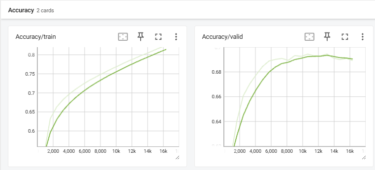

Accuracy

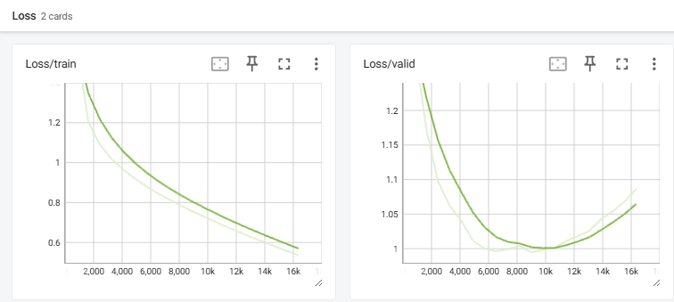

Loss

## Testing Code

We use the best model **model.ckpt** obtained through training to accomplish the classification of phoneme.

```python
def predict(test_loader, model, device):
    model.eval() # Set your model to evaluation mode.
    labels = []
    with torch.no_grad():
        for x in test_loader:
            x = x.to(device)
            test_pred = model(x)
            # Find the maximum in test_pred
            test_label = np.argmax(test_pred.detach().cpu().numpy(), axis=1)
            labels.append(test_label)
        labels = np.concatenate(labels, axis=0)
        return labels

model = Classifier(input_dim=39 * config['concat_frames'], hidden_layers=config['hidden_layers'], hidden_dim= config['hidden_dim']).to(device)
model.load_state_dict(torch.load(config['save_path'], weights_only=True))
preds = predict(test_loader, model, device)
```

### Saving Results

```python
def save_pred(preds, file):
    with open(file, 'w') as fp:
        writer = csv.writer(fp)
        writer.writerow(['id', 'tested_results'])
        for i, p in enumerate(preds):
            writer.writerow([i, p])

save_pred(preds, './libriphone/pred.csv')
display_results = pd.read_csv('./libriphone/pred.csv')

print("Prediction Results")
print(display_results)
```

```
Prediction Results
            id  tested_results
0            0               0
1            1               0
2            2               0
3            3               0
4            4               0
...        ...             ...
527359  527359               0
527360  527360               0
527361  527361               0
527362  527362               0
527363  527363               0

[527364 rows x 2 columns]
```

Back to top